# Part A

**DOMAIN**: Medical

**CONTEXT**: Medical research university X is undergoing a deep research on patients with certain conditions. University has an internal AI team. Due to confidentiality the patient’s details and the conditions are masked by the client by providing different datasets to the AI team for developing a AIML model which can predict the condition of the patient depending on the received test results.

**DATA DESCRIPTION**: The data consists of biomechanics features of the patients according to their current conditions. Each patient is represented in the data set by six biomechanics attributes derived from the shape and orientation of the condition to their body part.

**PROJECT OBJECTIVE**: To Demonstrate the ability to fetch, process and leverage data to generate useful predictions by training Supervised Learning algorithms.

## **1. Data Understanding:**

### **A. Read all the 3 CSV files as DataFrame and store them into 3 separate variables.**

```python
# Import Libraries
import pandas as pd #Pandas Library
import numpy as np #Numerical Python Library
print("Libraries imported successfully!")
```

```
Libraries imported successfully!
```

```python
# Read CSV Files
# Read first file and store the dataframe in a variable
Normal = pd.read_csv('/content/drive/MyDrive/Colab Notebooks/AIML-Supervised Learning Project/Normal.csv')
Normal.head()
```

|  | P_incidence | P_tilt | L_angle | S_slope | P_radius | S_Degree | Class |
| --- | --- | --- | --- | --- | --- | --- | --- |
| 0 | 38.505273 | 16.964297 | 35.112814 | 21.540976 | 127.632875 | 7.986683 | Normal |
| 1 | 54.920858 | 18.968430 | 51.601455 | 35.952428 | 125.846646 | 2.001642 | Normal |
| 2 | 44.362490 | 8.945435 | 46.902096 | 35.417055 | 129.220682 | 4.994195 | Normal |
| 3 | 48.318931 | 17.452121 | 48.000000 | 30.866809 | 128.980308 | -0.910941 | Normal |
| 4 | 45.701789 | 10.659859 | 42.577846 | 35.041929 | 130.178314 | -3.388910 | Normal |

```python
# Read second file and store the dataframe in a variable
Type_H = pd.read_csv('/content/drive/MyDrive/Colab Notebooks/AIML-Supervised Learning Project/Type_H.csv')
Type_H.head()
```

|  | P_incidence | P_tilt | L_angle | S_slope | P_radius | S_Degree | Class |
| --- | --- | --- | --- | --- | --- | --- | --- |
| 0 | 63.027817 | 22.552586 | 39.609117 | 40.475232 | 98.672917 | -0.254400 | Type_H |
| 1 | 39.056951 | 10.060991 | 25.015378 | 28.995960 | 114.405425 | 4.564259 | Type_H |
| 2 | 68.832021 | 22.218482 | 50.092194 | 46.613539 | 105.985135 | -3.530317 | Type_H |
| 3 | 69.297008 | 24.652878 | 44.311238 | 44.644130 | 101.868495 | 11.211523 | Type_H |
| 4 | 49.712859 | 9.652075 | 28.317406 | 40.060784 | 108.168725 | 7.918501 | Type_H |

```python
# Read third file and store the dataframe in a variable
Type_S = pd.read_csv('/content/drive/MyDrive/Colab Notebooks/AIML-Supervised Learning Project/Type_S.csv')
Type_S.head()
```

|  | P_incidence | P_tilt | L_angle | S_slope | P_radius | S_Degree | Class |
| --- | --- | --- | --- | --- | --- | --- | --- |
| 0 | 74.377678 | 32.053104 | 78.772013 | 42.324573 | 143.560690 | 56.125906 | Type_S |
| 1 | 89.680567 | 32.704435 | 83.130732 | 56.976132 | 129.955476 | 92.027277 | Type_S |
| 2 | 44.529051 | 9.433234 | 52.000000 | 35.095817 | 134.711772 | 29.106575 | Type_S |
| 3 | 77.690577 | 21.380645 | 64.429442 | 56.309932 | 114.818751 | 26.931841 | Type_S |
| 4 | 76.147212 | 21.936186 | 82.961502 | 54.211027 | 123.932010 | 10.431972 | Type_S |

*The three files (Normal, Type_H & Type_S) have been read succesfully and stored as seprate dataframes in their respective variables.*

### **B. Print Shape and columns of all the 3 DataFrames.**

```python
#Shape of first dataframe
Normal.shape
```

```
(100, 7)
```

*100 rows and 7 columns are present in the dataframe Normal.*

```python
#Columns of first dataframe
Normal.columns
```

```
Index(['P_incidence', 'P_tilt', 'L_angle', 'S_slope', 'P_radius', 'S_Degree',
       'Class'],
      dtype='object')
```

```python
#Shape of second dataframe
Type_H.shape
```

```
(60, 7)
```

*60 rows and 7 columns are present in the dataframe Type_H.*

```python
#Columns of second dataframe
Type_H.columns
```

```
Index(['P_incidence', 'P_tilt', 'L_angle', 'S_slope', 'P_radius', 'S_Degree',
       'Class'],
      dtype='object')
```

```python
#Shape of third dataframe
Type_S.shape
```

```
(150, 7)
```

*150 rows and 7 columns are present in the dataframe Type_S.*

```python
#Columns of third dataframe
Type_S.columns
```

```
Index(['P_incidence', 'P_tilt', 'L_angle', 'S_slope', 'P_radius', 'S_Degree',
       'Class'],
      dtype='object')
```

*The three dataframes have different number of rows but same number of columns*

### **C. Compare Column names of all the 3 DataFrames and clearly write observations.**

- *The column names are same in all the three dataframes.*
- *The number of columns is same (7) across the three dataframes.*

### **D. Print DataTypes of all the 3 DataFrames.**

```python
# Datatypes of first dataframe
Normal.dtypes
```

```
P_incidence    float64
P_tilt         float64
L_angle        float64
S_slope        float64
P_radius       float64
S_Degree       float64
Class           object
dtype: object
```

```python
# Datatypes of second dataframe
Type_H.dtypes
```

```
P_incidence    float64
P_tilt         float64
L_angle        float64
S_slope        float64
P_radius       float64
S_Degree       float64
Class           object
dtype: object
```

```python
# Datatypes of first dataframe
Type_S.dtypes
```

```
P_incidence    float64
P_tilt         float64
L_angle        float64
S_slope        float64
P_radius       float64
S_Degree       float64
Class           object
dtype: object
```

- *Except the variable Class which is of the object datatype, all the other columns have a float datatype*
- *Datatypes are same across the three dataframes*

### **E. Observe and share variation in ‘Class’ feature of all the 3 DaraFrames.**

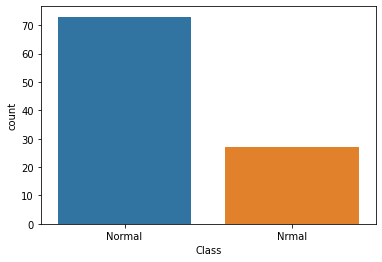

```python
import seaborn as sns #Library for plotting
# Plot Class feature of the first dataframe
sns.countplot(x='Class',data=Normal);
```

```python
Normal['Class'].value_counts() # Display count of categoories in the variable 'Class'
```

```
Normal    73
Nrmal     27
Name: Class, dtype: int64
```

*In the first dataframe, the Class feature is categorical. Ideally, it should have only one category - Normal. But as can be seen from the countplot above, there are two categories - Normal and Nrmal. Nrmal seems to be a spelling mistake. This would need correction before modelling.*

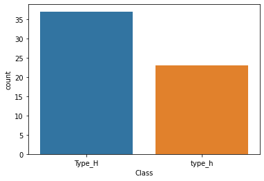

```python
# Plot Class feature of the second dataframe
sns.countplot(x='Class',data=Type_H);
```

```python
Type_H['Class'].value_counts() # Display count of categories in the variable 'Class'
```

```
Type_H    37
type_h    23
Name: Class, dtype: int64
```

*In the second dataframe, the Class feature is also categorical. Ideally, it should have only one category - Type_H. But as can be seen from the countplot above, there are two categories - Type_H and type_h. type_h seems to be a data entry error as there should be only one category in the second dataframe. This would need correction before modelling.*

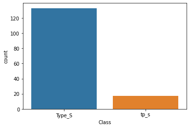

```python
# Plot Class feature of the third dataframe
sns.countplot(x='Class',data=Type_S);
```

```python
Type_S['Class'].value_counts() # Display count of categories in the variable 'Class'
```

```
Type_S    133
tp_s       17
Name: Class, dtype: int64
```

## **2. Data Preparation and Exploration:**

### **A. Unify all the variations in ‘Class’ feature for all the 3 DataFrames.**

```python
# Unify variations in 'Class' feature of first dataframe
Normal['Class'].replace('Nrmal','Normal',inplace=True) # Replace 'Nrmal' with 'Normal'
Normal['Class'].value_counts() # Display count of categoories in the variable 'Class'
```

```
Normal    100
Name: Class, dtype: int64
```

```python
# Unify variations in 'Class' feature of second dataframe
Type_H['Class'].replace('type_h','Type_H',inplace=True) # Replace 'type_h' with 'Type_H'
Type_H['Class'].value_counts() # Display count of categories in the variable 'Class'
```

```
Type_H    60
Name: Class, dtype: int64
```

```python
# Unify variations in 'Class' feature of third dataframe
Type_S['Class'].replace('tp_s','Type_S',inplace=True) # Replace 'type_h' with 'Type_H'
Type_S['Class'].value_counts() # Display count of categories in the variable 'Class'
```

```
Type_S    150
Name: Class, dtype: int64
```

### **B. Combine all the 3 DataFrames to form a single DataFrame**

```python
# Let the single dataframe name be patient_data. I'll combine the three dataframes under this name.
patient_data=pd.concat([Normal,Type_H,Type_S],axis=0,ignore_index=True)# Axis=0 for Vertical Concatenation
patient_data.shape # Checkpoint Verification: Dataframe shape is combination of rows from all three dataframes
```

```
(310, 7)
```

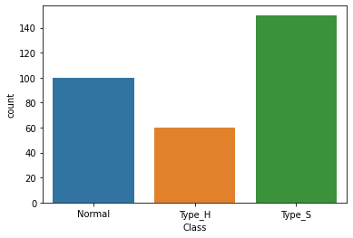

```python
sns.countplot(data=patient_data,x='Class'); # Plot categories of 'Class' variable from the combined dataframe
```

### **C. Print 5 random samples of this DataFrame**

```python
# Using sample() method to randomly sample 5 rows from combined dataframe
patient_data.sample(n=5)
```

|  | P_incidence | P_tilt | L_angle | S_slope | P_radius | S_Degree | Class |
| --- | --- | --- | --- | --- | --- | --- | --- |
| 137 | 35.703458 | 19.443253 | 20.700000 | 16.260205 | 137.540613 | -0.263490 | Type_H |
| 26 | 61.821627 | 13.597105 | 64.000000 | 48.224523 | 121.779803 | 1.296191 | Normal |
| 201 | 79.938570 | 18.774071 | 63.311835 | 61.164499 | 114.787107 | 38.538741 | Type_S |
| 10 | 44.489275 | 21.786433 | 31.474154 | 22.702842 | 113.778494 | -0.284129 | Normal |
| 29 | 56.447026 | 19.444499 | 43.577846 | 37.002527 | 139.189690 | -1.859689 | Normal |

### **D. Print Feature-wise percentage of Null values.**

```python
# Calculate percentage of null values for each column
patient_data.isnull().sum()*100/len(patient_data)
```

```
P_incidence    0.0
P_tilt         0.0
L_angle        0.0
S_slope        0.0
P_radius       0.0
S_Degree       0.0
Class          0.0
dtype: float64
```

### **E. Check 5-point summary of the new DataFrame.**

```python
# 5-point Summary
summary=patient_data.describe().transpose() # Get descriptive statistics
summary.iloc[:,[3,4,5,6,7]] # Extract 5-point summary statistics
```

|  | min | 25% | 50% | 75% | max |
| --- | --- | --- | --- | --- | --- |
| P_incidence | 26.147921 | 46.430294 | 58.691038 | 72.877696 | 129.834041 |
| P_tilt | -6.554948 | 10.667069 | 16.357689 | 22.120395 | 49.431864 |
| L_angle | 14.000000 | 37.000000 | 49.562398 | 63.000000 | 125.742385 |
| S_slope | 13.366931 | 33.347122 | 42.404912 | 52.695888 | 121.429566 |
| P_radius | 70.082575 | 110.709196 | 118.268178 | 125.467674 | 163.071041 |
| S_Degree | -11.058179 | 1.603727 | 11.767934 | 41.287352 | 418.543082 |

## **3. Data Analysis:**

### **A. Visualize a heatmap to understand correlation between all features**

```python
# Calculate correlation matrix
correlation = patient_data.corr()
correlation
```

|  | P_incidence | P_tilt | L_angle | S_slope | P_radius | S_Degree |
| --- | --- | --- | --- | --- | --- | --- |
| P_incidence | 1.000000 | 0.629199 | 0.717282 | 0.814960 | -0.247467 | 0.638743 |
| P_tilt | 0.629199 | 1.000000 | 0.432764 | 0.062345 | 0.032668 | 0.397862 |
| L_angle | 0.717282 | 0.432764 | 1.000000 | 0.598387 | -0.080344 | 0.533667 |
| S_slope | 0.814960 | 0.062345 | 0.598387 | 1.000000 | -0.342128 | 0.523557 |
| P_radius | -0.247467 | 0.032668 | -0.080344 | -0.342128 | 1.000000 | -0.026065 |
| S_Degree | 0.638743 | 0.397862 | 0.533667 | 0.523557 | -0.026065 | 1.000000 |

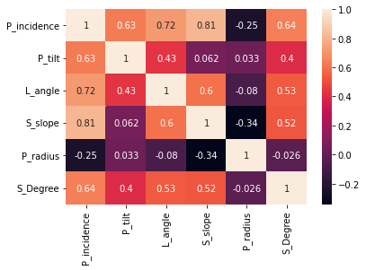

```python
#Plot Heat Map of Correlation Matrix
sns.heatmap(data=correlation,annot=True);
```

### **B. Share insights on correlation.**

- **A. Features having stronger correlation with correlation value.**

  *P_incidence has strong positive correlation with P_tilt(0.63), L_angle(0.72), S_slope(0.81) and S_Degree(0.64)*

  *L_angle has strong positive correlation with S_slope(0.6)*
- **B. Features having weaker correlation with correlation value.**

  *P_incidence has weak negative correlation with P_radius(-0.25)*

  *P_tilt has weak positive correlation with L_angle(0.43), S_Degree(0.4) and no correlation with S_slope(0.062), P_radius(0.033)*

  *L_angle has weak positive correlation with S_Degree(0.53) and no correlation P_radius(-0.08)*

  *S_slope has weak positive correlation with S_Degree(0.52) and weak negative correlation with P_radius(-0.34)*

  *P_radius has no correlation with S_degree(-0.026)*

### **C. Visualize a pairplot with 3 classes distinguished by colors and share insights.**

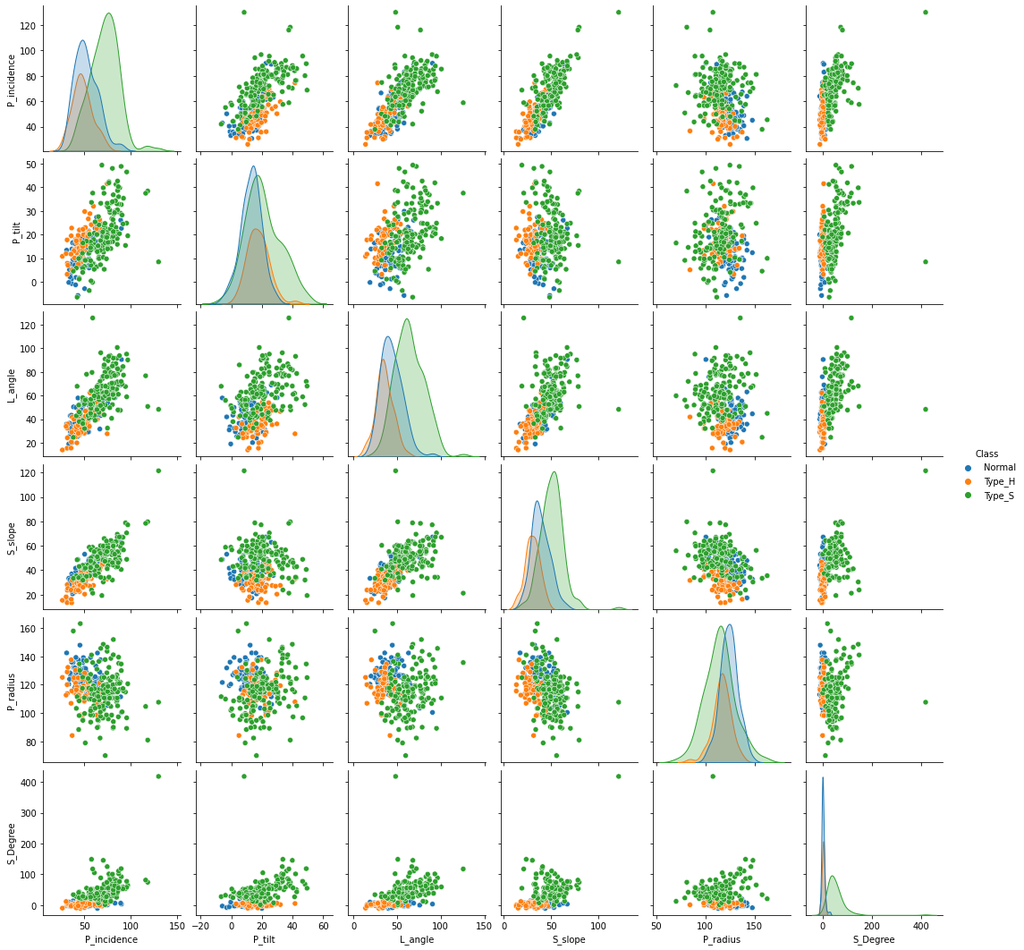

```python
# Plot a pairplot distinguished by the variable 'Class'
sns.pairplot(data=patient_data,hue='Class');
```

1. *Type_S class variables seems to be normally distributed except for the variable S_Degree*
2. *For P_radius all classes are normally distributed*
3. *For S_Degree, Normal and Type_H are heavily right-skewed*
4. *For P_incidence, S_slope and L_angle too, Normal and Type_H classes are right-skewed*
5. *From the scatter plots, data does not seem to be linearly separable between different classes*
6. *Overlapping groups of classes can be seen in most scatter plots*

### **D. Visualize a jointplot for ‘P_incidence’ and ‘S_slope’ and share insights.**

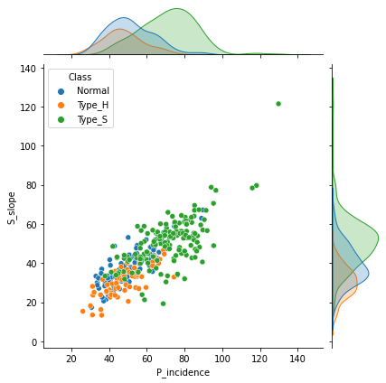

```python
# Plot JointPlot
sns.jointplot(x='P_incidence',y='S_slope',data=patient_data,hue='Class');
```

1. *P_incidence and S_slope are positively correlated*
2. *Classes overlap between these two variables and they are not linearly separable*
3. *Type_S seems to be a normally distributted class between these two variables*
4. *Normal and Type_H denoted classes are skewed for both P_incidence and S_slope*
5. *In terms of magnitude, Type_S denoted variable has the maximum value and Type_H denoted variable has the minimum value class.*

### **E. Visualize a boxplot to check distribution of the features and share insights.**

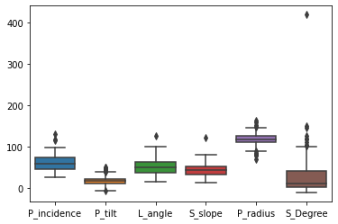

```python
# Plot a boxplot for the entire dataframe
sns.boxplot(data=patient_data);
```

- *P_radius, P_tilt, S_Degree have numerous outliers*
- *P_incidence, L_angle, S_slope have relatively fewer outliers*
- *All the numerical variables have different scales, with P_radius having very high values and P_tilt having low values*
- *S_Degree column has skewed data as there is relatively more data above (higher Q3) the median line than below it*
- *Other variables seem to be normally distributed as the median lies along the center of the box*

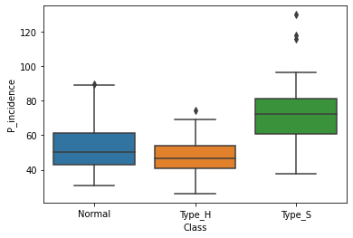

```python
# Plot boxplot for each numerical feature and mark different categories in class
sns.boxplot(x='Class',y='P_incidence',data=patient_data);
```

- *Type_S class has more outliers than the other two classes*
- *Data is normally distributed among the three classes*

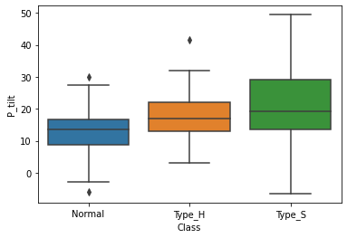

```python
# Plot boxplot for each numerical feature and mark different categories in class
sns.boxplot(x='Class',y='P_tilt',data=patient_data);
```

- *P_tilt does not have many outliers and is normally distributed across different classes*

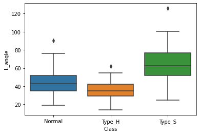

```python
# Plot boxplot for each numerical feature and mark different categories in class
sns.boxplot(x='Class',y='L_angle',data=patient_data);
```

- *L_angle does not have many outliers and is normally distributed across different classes*
- *Type_S class values have a higher scale (magnitude) as the box is situated above the boxes of the other two classes*

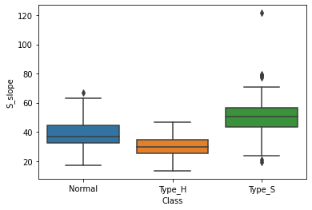

```python
# Plot boxplot for each numerical feature and mark different categories in class
sns.boxplot(x='Class',y='S_slope',data=patient_data);
```

- *Type_S class has more outliers*
- *Data is normally distributed*

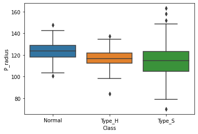

```python
# Plot boxplot for each numerical feature and mark different categories in class
sns.boxplot(x='Class',y='P_radius',data=patient_data);
```

- *Type_S has class has more number of outliers*
- *Data is normally distributed*

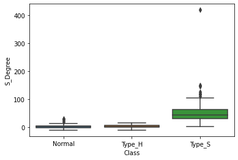

```python
# Plot boxplot for each numerical feature and mark different categories in class
sns.boxplot(x='Class',y='S_Degree',data=patient_data);
```

- *In S_Degree, Normal and Type_H classes have smaller scale (magnitude) than Type_S class*
- *Type_S class has more outliers than the other two classes*

## **4. Model Building:**

### **A. Split data into X and Y.**

```python
# Split data into X
# 'Class' variable is the Target Variable (y) and remaining are independent variables (x1,x2,...)
X = patient_data.drop(labels= "Class" , axis = 1)
X.head()
```

|  | P_incidence | P_tilt | L_angle | S_slope | P_radius | S_Degree |
| --- | --- | --- | --- | --- | --- | --- |
| 0 | 38.505273 | 16.964297 | 35.112814 | 21.540976 | 127.632875 | 7.986683 |
| 1 | 54.920858 | 18.968430 | 51.601455 | 35.952428 | 125.846646 | 2.001642 |
| 2 | 44.362490 | 8.945435 | 46.902096 | 35.417055 | 129.220682 | 4.994195 |
| 3 | 48.318931 | 17.452121 | 48.000000 | 30.866809 | 128.980308 | -0.910941 |
| 4 | 45.701789 | 10.659859 | 42.577846 | 35.041929 | 130.178314 | -3.388910 |

```python
# Create Target Variable (y) of the variable 'Class' from the dataframe
y = patient_data['Class']
y
```

```
0      Normal
1      Normal
2      Normal
3      Normal
4      Normal
        ...
305    Type_S
306    Type_S
307    Type_S
308    Type_S
309    Type_S
Name: Class, Length: 310, dtype: object
```

### **B. Split data into train and test with 80:20 proportion.**

```python
# Import Library to Split Data
from sklearn.model_selection import train_test_split

# Split X and y into training and test set in 80:20 ratio
X_train, X_test, y_train, y_test = train_test_split(X, y, test_size=0.20, random_state=1)
print('Shape of X_train',X_train.shape)
print('Shape of y_train',y_train.shape)
print('Shape of X_test',X_test.shape)
print('Shape of y_test',y_test.shape)
```

```
Shape of X_train (248, 6)
Shape of y_train (248,)
Shape of X_test (62, 6)
Shape of y_test (62,)
```

### **C. Train a Supervised Learning Classification base model using KNN classifier.**

```python
# Import KNN Classifier from sklearn
from sklearn.neighbors import KNeighborsClassifier

# Instantiate learning model
knn1 = KNeighborsClassifier()

# fitting the model
knn1.fit(X_train, y_train)
```

```
KNeighborsClassifier()
```

### **D. Print all the possible performance metrics for both train and test data.**

```python
# Predict the Test Dataset
y_pred = knn1.predict(X_test)
y_pred
```

```
array(['Normal', 'Type_S', 'Normal', 'Normal', 'Normal', 'Normal',
       'Type_S', 'Type_H', 'Type_H', 'Type_S', 'Type_S', 'Type_S',
       'Normal', 'Normal', 'Type_S', 'Type_H', 'Type_S', 'Type_S',
       'Type_S', 'Normal', 'Type_S', 'Type_S', 'Normal', 'Type_S',
       'Normal', 'Type_S', 'Normal', 'Type_S', 'Normal', 'Type_S',
       'Type_S', 'Type_S', 'Type_S', 'Type_S', 'Normal', 'Normal',
       'Normal', 'Type_S', 'Type_H', 'Type_H', 'Type_S', 'Type_S',
       'Normal', 'Type_S', 'Type_S', 'Type_H', 'Type_S', 'Type_S',
       'Type_S', 'Type_S', 'Normal', 'Type_S', 'Normal', 'Normal',
       'Normal', 'Normal', 'Normal', 'Normal', 'Type_H', 'Type_H',
       'Normal', 'Type_S'], dtype=object)
```

```python
# Print Train Data Performance
knn1.score(X_train,y_train)
```

```
0.8911290322580645
```

```python
# Print Test Data Performance
knn1.score(X_test,y_test)
```

```
0.8387096774193549
```

```python
# Predict from Training Dataset
y_pred_train = knn1.predict(X_train)
y_pred_train
```

```
array(['Type_S', 'Type_H', 'Type_H', 'Type_S', 'Normal', 'Type_S',
       'Type_S', 'Type_S', 'Type_H', 'Normal', 'Type_S', 'Type_S',
       'Type_S', 'Type_H', 'Type_H', 'Type_S', 'Type_S', 'Type_S',
       'Normal', 'Type_H', 'Type_S', 'Type_S', 'Normal', 'Type_H',
       'Type_H', 'Normal', 'Normal', 'Type_S', 'Normal', 'Type_S',
       'Normal', 'Normal', 'Type_S', 'Type_H', 'Normal', 'Type_S',
       'Type_S', 'Type_S', 'Normal', 'Type_S', 'Type_S', 'Type_S',
       'Normal', 'Normal', 'Normal', 'Type_S', 'Type_S', 'Normal',
       'Type_S', 'Type_H', 'Normal', 'Type_H', 'Type_H', 'Type_S',
       'Normal', 'Normal', 'Type_S', 'Type_H', 'Type_S', 'Type_H',
       'Type_H', 'Normal', 'Normal', 'Normal', 'Type_S', 'Type_S',
       'Normal', 'Type_H', 'Normal', 'Normal', 'Type_S', 'Normal',
       'Type_S', 'Type_S', 'Normal', 'Normal', 'Type_S', 'Normal',
       'Type_S', 'Type_S', 'Normal', 'Type_S', 'Type_H', 'Type_S',
       'Type_S', 'Type_S', 'Normal', 'Type_S', 'Type_S', 'Normal',
       'Normal', 'Type_H', 'Normal', 'Normal', 'Normal', 'Normal',
       'Type_S', 'Type_H', 'Type_S', 'Type_H', 'Type_S', 'Type_H',
       'Type_S', 'Type_S', 'Type_S', 'Normal', 'Type_H', 'Type_S',
       'Type_S', 'Normal', 'Type_S', 'Type_H', 'Type_S', 'Type_S',
       'Type_S', 'Type_H', 'Type_S', 'Type_S', 'Type_H', 'Type_S',
       'Type_S', 'Normal', 'Type_S', 'Type_S', 'Type_S', 'Type_S',
       'Type_S', 'Type_S', 'Normal', 'Type_S', 'Normal', 'Normal',
       'Normal', 'Normal', 'Type_S', 'Normal', 'Normal', 'Type_S',
       'Type_H', 'Type_S', 'Type_H', 'Type_S', 'Type_H', 'Type_S',
       'Type_H', 'Normal', 'Type_H', 'Normal', 'Type_H', 'Normal',
       'Type_H', 'Type_S', 'Normal', 'Type_S', 'Type_S', 'Type_S',
       'Type_H', 'Type_H', 'Type_S', 'Normal', 'Type_S', 'Type_S',
       'Normal', 'Type_S', 'Type_S', 'Type_S', 'Type_S', 'Type_H',
       'Type_S', 'Type_S', 'Normal', 'Type_S', 'Type_S', 'Normal',
       'Normal', 'Normal', 'Type_H', 'Type_S', 'Normal', 'Type_H',
       'Normal', 'Type_S', 'Type_H', 'Type_S', 'Type_S', 'Normal',
       'Type_S', 'Normal', 'Normal', 'Type_S', 'Type_S', 'Type_S',
       'Type_H', 'Type_S', 'Normal', 'Normal', 'Type_S', 'Normal',
       'Type_H', 'Type_H', 'Type_S', 'Type_S', 'Type_H', 'Type_H',
       'Type_S', 'Normal', 'Type_S', 'Normal', 'Normal', 'Type_H',
       'Normal', 'Normal', 'Normal', 'Normal', 'Normal', 'Type_S',
       'Normal', 'Normal', 'Normal', 'Type_S', 'Type_S', 'Type_S',
       'Type_S', 'Normal', 'Normal', 'Normal', 'Normal', 'Normal',
       'Type_S', 'Type_S', 'Normal', 'Normal', 'Type_H', 'Type_S',
       'Type_S', 'Type_S', 'Type_S', 'Type_S', 'Type_S', 'Normal',
       'Type_H', 'Normal', 'Normal', 'Type_S', 'Type_S', 'Normal',
       'Type_S', 'Normal'], dtype=object)
```

```
Confusion Matrix for Training Data
```

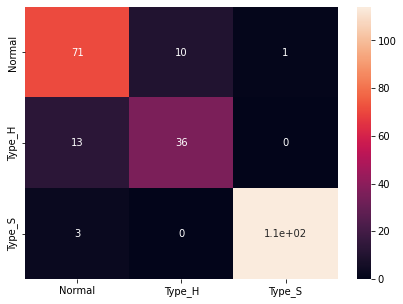

```python
# Confusion matrix for Train Data
from sklearn import metrics

print("Confusion Matrix for Training Data")
cm=metrics.confusion_matrix(y_train, y_pred_train, labels=["Normal", "Type_H", "Type_S"])

df_cm = pd.DataFrame(cm, index = [i for i in ["Normal", "Type_H", "Type_S"]],
                  columns = [i for i in ["Normal", "Type_H", "Type_S"]])

import matplotlib.pyplot as plt
%matplotlib inline
plt.figure(figsize = (7,5));
sns.heatmap(df_cm, annot=True);
```

```
Confusion Matrix for Test Data
```

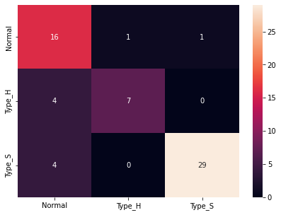

```python
# Confusion matrix for Test Data

print("Confusion Matrix for Test Data")
cm=metrics.confusion_matrix(y_test, y_pred, labels=["Normal", "Type_H", "Type_S"])

df_cm = pd.DataFrame(cm, index = [i for i in ["Normal", "Type_H", "Type_S"]],
                  columns = [i for i in ["Normal", "Type_H", "Type_S"]])

plt.figure(figsize = (7,5));
sns.heatmap(df_cm, annot=True);
```

```python
# Calculate performance metrics for training data
# Import inbuilt classification report from sklearn
from sklearn.metrics import classification_report
target_names = ['Normal','Type_H','Type_S']
print(classification_report(y_train, y_pred_train, target_names=target_names))
```

```
              precision    recall  f1-score   support

      Normal       0.82      0.87      0.84        82
      Type_H       0.78      0.73      0.76        49
      Type_S       0.99      0.97      0.98       117

    accuracy                           0.89       248
   macro avg       0.86      0.86      0.86       248
weighted avg       0.89      0.89      0.89       248
```

```python
# Calculate performance metrics test data
# Import inbuilt classification report from sklearn
print(classification_report(y_test, y_pred, target_names=target_names))
```

```
              precision    recall  f1-score   support

      Normal       0.67      0.89      0.76        18
      Type_H       0.88      0.64      0.74        11
      Type_S       0.97      0.88      0.92        33

    accuracy                           0.84        62
   macro avg       0.84      0.80      0.81        62
weighted avg       0.86      0.84      0.84        62
```

## **5. Performance Improvement:**

### **A. Experiment with various parameters to improve performance of the base model.**

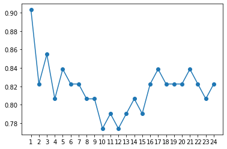

```python
# Check for optimal value of k
kscores = []
for i in range(1,25):
  knn = KNeighborsClassifier(n_neighbors = i)
  knn.fit(X_train, y_train)
  s = knn.score(X_test, y_test)
  kscores.append(s)
plt.plot(range(1,25), kscores, 'o-')
plt.xticks(range(1,25))
plt.show()
```

*For k=1, the accuracy score is the highest. We build a model with k=1*

```python
# Instantiate learning model
knn2 = KNeighborsClassifier(n_neighbors = 1)

# fitting the model
knn2.fit(X_train, y_train)
```

```
KNeighborsClassifier(n_neighbors=1)
```

```python
# Predict the Test Dataset
y_pred2 = knn2.predict(X_test)
y_pred2
```

```
array(['Normal', 'Type_S', 'Type_S', 'Normal', 'Normal', 'Type_H',
       'Type_S', 'Type_H', 'Normal', 'Type_S', 'Type_S', 'Type_S',
       'Normal', 'Normal', 'Type_S', 'Type_H', 'Type_S', 'Type_S',
       'Type_S', 'Normal', 'Type_S', 'Type_S', 'Normal', 'Type_S',
       'Normal', 'Type_S', 'Normal', 'Type_S', 'Normal', 'Type_S',
       'Type_S', 'Type_S', 'Type_S', 'Type_S', 'Normal', 'Type_S',
       'Normal', 'Type_S', 'Type_H', 'Type_H', 'Type_S', 'Type_S',
       'Normal', 'Type_S', 'Type_S', 'Type_H', 'Type_S', 'Type_S',
       'Type_S', 'Type_S', 'Normal', 'Type_S', 'Normal', 'Type_H',
       'Normal', 'Normal', 'Normal', 'Type_H', 'Normal', 'Type_H',
       'Normal', 'Type_S'], dtype=object)
```

```python
# Print Train Data Performance
knn2.score(X_train,y_train)
```

```
1.0
```

```python
# Print Test Data Performance
knn2.score(X_test,y_test)
```

```
0.9032258064516129
```

```python
# Calculate performance metrics
print(classification_report(y_test, y_pred2, target_names=target_names))
```

```
              precision    recall  f1-score   support

      Normal       0.81      0.94      0.87        18
      Type_H       0.89      0.73      0.80        11
      Type_S       0.97      0.94      0.95        33

    accuracy                           0.90        62
   macro avg       0.89      0.87      0.88        62
weighted avg       0.91      0.90      0.90        62
```

```python
# Change weights parameter in the above model
knn3 = KNeighborsClassifier(n_neighbors = 1, weights='distance')

# fitting the model
knn3.fit(X_train, y_train)
# Predict the Test Dataset
y_pred3 = knn3.predict(X_test)
# Print Train Data Performance
print("Accuracy on Training Data:",knn3.score(X_train,y_train))
# Print Test Data Performance
print("Accuracy on Test Data:",knn3.score(X_test,y_test))
# Calculate performance metrics
print(classification_report(y_test, y_pred3, target_names=target_names))
```

```
Accuracy on Training Data: 1.0
Accuracy on Test Data: 0.9032258064516129
              precision    recall  f1-score   support

      Normal       0.81      0.94      0.87        18
      Type_H       0.89      0.73      0.80        11
      Type_S       0.97      0.94      0.95        33

    accuracy                           0.90        62
   macro avg       0.89      0.87      0.88        62
weighted avg       0.91      0.90      0.90        62
```

*Not much improvement is seen by introducing the weights parameter.*

### **B. Clearly showcase improvement in performance achieved.**

```python
# We will compare the first two models, default k(=5) and k=1.
print("Default KNN (k=5) Model Performance")
print(classification_report(y_test, y_pred, target_names=target_names))
```

```
Default KNN (k=5) Model Performance
              precision    recall  f1-score   support

      Normal       0.67      0.89      0.76        18
      Type_H       0.88      0.64      0.74        11
      Type_S       0.97      0.88      0.92        33

    accuracy                           0.84        62
   macro avg       0.84      0.80      0.81        62
weighted avg       0.86      0.84      0.84        62
```

```python
print("Modified KNN (k=1) Model Performance")
print(classification_report(y_test, y_pred2, target_names=target_names))
```

```
Modified KNN (k=1) Model Performance
              precision    recall  f1-score   support

      Normal       0.81      0.94      0.87        18
      Type_H       0.89      0.73      0.80        11
      Type_S       0.97      0.94      0.95        33

    accuracy                           0.90        62
   macro avg       0.89      0.87      0.88        62
weighted avg       0.91      0.90      0.90        62
```

1. Accuracy Improvement = 6%
2. Precision Improvement
   - Normal Class = 14%
   - Type_H Class = 1%
   - Type_S Class = 0%
3. Recall Improvement
   - Normal Class = 5%
   - Type_H Class = 9%
   - Type_S Class = 6%
4. F1-Score Improvement
   - Normal Class = 11%
   - Type_H Class = 6%
   - Type_S Class = 3%

### **C. Clearly state which parameters contributed most to improve model performance.**

*By changing the k parameter from default value of 5 to 1, there was a significant improvement in model performance.*

*Adding 'weights' parameters did not improve the model performance any further.*

# Part B

**DOMAIN**: Banking, Marketing

**CONTEXT**: A bank X is on a massive digital transformation for all its departments. Bank has a growing customer base whee majority of them are liability customers (depositors) vs borrowers (asset customers). The bank is interested in expanding the borrowers base rapidly to bring in more business via loan interests. A campaign that the bank ran in last quarter showed an average single digit conversion rate. Digital transformation being the core strength of the business strategy, marketing department wants to devise effective campaigns with better target marketing to increase the conversion ratio to double digit with same budget as per last campaign.

**DATA DICTIONARY**:

1. **Team**: Team’s name
2. **ID**: Customer ID
3. **Age**: Customer’s approximate age.
4. **CustomerSince**: Customer of the bank since. [unit is masked]
5. **HighestSpend**: Customer’s highest spend so far in one transaction. [unit is masked]
6. **ZipCode**: Customer’s zip code.
7. **HiddenScore**: A score associated to the customer which is masked by the bank as an IP.
8. **MonthlyAverageSpend**: Customer’s monthly average spend so far. [unit is masked]
9. **Level**: A level associated to the customer which is masked by the bank as an IP.
10. **Mortgage**: Customer’s mortgage. [unit is masked]
11. **Security**: Customer’s security asset with the bank. [unit is masked]
12. **FixedDepositAccount**: Customer’s fixed deposit account with the bank. [unit is masked]
13. **InternetBanking**: if the customer uses internet banking.
14. **CreditCard**: if the customer uses bank’s credit card.
15. **LoanOnCard**: if the customer has a loan on credit card.

**PROJECT OBJECTIVE**: Build a Machine Learning model to perform focused marketing by predicting the potential customers who will convert using the historical dataset.

## **1. Data Understanding and Preparation:**

### **A. Read both the Datasets ‘Data1’ and ‘Data 2’ as DataFrame and store them into two separate variables.**

```python
# Read CSV Files
# Read first file and store the dataframe in a variable
data1 = pd.read_csv('/content/drive/MyDrive/Colab Notebooks/AIML-Supervised Learning Project/Data1.csv')
data1.head()
```

|  | ID | Age | CustomerSince | HighestSpend | ZipCode | HiddenScore | MonthlyAverageSpend | Level |
| --- | --- | --- | --- | --- | --- | --- | --- | --- |
| 0 | 1 | 25 | 1 | 49 | 91107 | 4 | 1.6 | 1 |
| 1 | 2 | 45 | 19 | 34 | 90089 | 3 | 1.5 | 1 |
| 2 | 3 | 39 | 15 | 11 | 94720 | 1 | 1.0 | 1 |
| 3 | 4 | 35 | 9 | 100 | 94112 | 1 | 2.7 | 2 |
| 4 | 5 | 35 | 8 | 45 | 91330 | 4 | 1.0 | 2 |

```python
# Read second file and store the dataframe in a variable
data2 = pd.read_csv('/content/drive/MyDrive/Colab Notebooks/AIML-Supervised Learning Project/Data2.csv')
data2.head()
```

|  | ID | Mortgage | Security | FixedDepositAccount | InternetBanking | CreditCard | LoanOnCard |
| --- | --- | --- | --- | --- | --- | --- | --- |
| 0 | 1 | 0 | 1 | 0 | 0 | 0 | NaN |
| 1 | 2 | 0 | 1 | 0 | 0 | 0 | NaN |
| 2 | 3 | 0 | 0 | 0 | 0 | 0 | NaN |
| 3 | 4 | 0 | 0 | 0 | 0 | 0 | NaN |
| 4 | 5 | 0 | 0 | 0 | 0 | 1 | NaN |

*'Data1' and 'Data2' .csv files have been read and stored in two separate variables - data1, data2*

### **B. Print shape and Column Names and DataTypes of both the Dataframes.**

```python
# Print shape of first dataframe
data1.shape
```

```
(5000, 8)
```

```python
# Print column names of first dataframe
data1.columns
```

```
Index(['ID', 'Age', 'CustomerSince', 'HighestSpend', 'ZipCode', 'HiddenScore',
       'MonthlyAverageSpend', 'Level'],
      dtype='object')
```

```python
# Print DataTypes of first dataframe
data1.dtypes
```

```
ID                       int64
Age                      int64
CustomerSince            int64
HighestSpend             int64
ZipCode                  int64
HiddenScore              int64
MonthlyAverageSpend    float64
Level                    int64
dtype: object
```

```python
# Print shape of second dataframe
data2.shape
```

```
(5000, 7)
```

```python
# Print column names of second dataframe
data2.columns
```

```
Index(['ID', 'Mortgage', 'Security', 'FixedDepositAccount', 'InternetBanking',
       'CreditCard', 'LoanOnCard'],
      dtype='object')
```

```python
# Print DataTypes of second dataframe
data2.dtypes
```

```
ID                       int64
Mortgage                 int64
Security                 int64
FixedDepositAccount      int64
InternetBanking          int64
CreditCard               int64
LoanOnCard             float64
dtype: object
```

### **C. Merge both the Dataframes on ‘ID’ feature to form a single DataFrame**

```python
bank_data = pd.merge(data1, data2, on='ID')
bank_data.head()
```

|  | ID | Age | CustomerSince | HighestSpend | ZipCode | HiddenScore | MonthlyAverageSpend | Level | Mortgage | Security | FixedDepositAccount | InternetBanking | CreditCard | LoanOnCard |
| --- | --- | --- | --- | --- | --- | --- | --- | --- | --- | --- | --- | --- | --- | --- |
| 0 | 1 | 25 | 1 | 49 | 91107 | 4 | 1.6 | 1 | 0 | 1 | 0 | 0 | 0 | NaN |
| 1 | 2 | 45 | 19 | 34 | 90089 | 3 | 1.5 | 1 | 0 | 1 | 0 | 0 | 0 | NaN |
| 2 | 3 | 39 | 15 | 11 | 94720 | 1 | 1.0 | 1 | 0 | 0 | 0 | 0 | 0 | NaN |
| 3 | 4 | 35 | 9 | 100 | 94112 | 1 | 2.7 | 2 | 0 | 0 | 0 | 0 | 0 | NaN |
| 4 | 5 | 35 | 8 | 45 | 91330 | 4 | 1.0 | 2 | 0 | 0 | 0 | 0 | 1 | NaN |

```python
# Verify if the number of rows are same, columns have increased and datatypes are preserved
bank_data.info()
```

```
<class 'pandas.core.frame.DataFrame'>
Int64Index: 5000 entries, 0 to 4999
Data columns (total 14 columns):
 #   Column               Non-Null Count  Dtype
---  ------               --------------  -----
 0   ID                   5000 non-null   int64
 1   Age                  5000 non-null   int64
 2   CustomerSince        5000 non-null   int64
 3   HighestSpend         5000 non-null   int64
 4   ZipCode              5000 non-null   int64
 5   HiddenScore          5000 non-null   int64
 6   MonthlyAverageSpend  5000 non-null   float64
 7   Level                5000 non-null   int64
 8   Mortgage             5000 non-null   int64
 9   Security             5000 non-null   int64
 10  FixedDepositAccount  5000 non-null   int64
 11  InternetBanking      5000 non-null   int64
 12  CreditCard           5000 non-null   int64
 13  LoanOnCard           4980 non-null   float64
dtypes: float64(2), int64(12)
memory usage: 585.9 KB
```

### **D. Change Datatype of below features to ‘Object’**

**‘CreditCard’, ‘InternetBanking’, ‘FixedDepositAccount’, ‘Security’, ‘Level’, ‘HiddenScore’**

[Reason behind performing this operation:- Values in these features are binary i.e. 1/0. But DataType is ‘int’/’float’ which is not expected.]

```python
# Create New DataType Dictionary
data_types_dict = {'CreditCard': str,"InternetBanking":str,"FixedDepositAccount":str,"Security":str,
                   "Level":str,"HiddenScore":str}

bank_data = bank_data.astype(data_types_dict)
bank_data.dtypes
```

```
ID                       int64
Age                      int64
CustomerSince            int64
HighestSpend             int64
ZipCode                  int64
HiddenScore             object
MonthlyAverageSpend    float64
Level                   object
Mortgage                 int64
Security                object
FixedDepositAccount     object
InternetBanking         object
CreditCard              object
LoanOnCard             float64
dtype: object
```

## **2. Data Exploration and Analysis:**

### **A. Visualize distribution of Target variable ‘LoanOnCard’ and clearly share insights.**

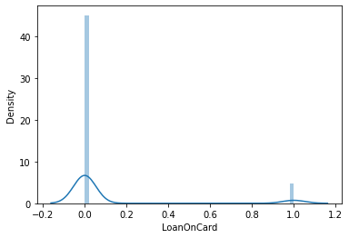

```python
# LoanOnCard is an Object DataType which means it is Categorical
sns.distplot(bank_data['LoanOnCard']);
```

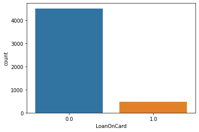

```python
# To check the distribution we visualize a CountPlot
sns.countplot(x=bank_data['LoanOnCard']);
```

```python
# Check actual count of classes/categories in LoanOnCard
bank_data['LoanOnCard'].value_counts()
```

```
0.0    4500
1.0     480
Name: LoanOnCard, dtype: int64
```

```python
# Are there any null values in LoanOnCard
bank_data['LoanOnCard'].isnull().sum()
```

```
20
```

*LoanOnCard variable is a categorical variable with two categories 0=No Loan on Credit Card and 1=Loan On Credit Card.*

*The distribution is asymmetric and skewed towards the category 0, implying unbalanced data.*

*There are 20 Null/NaN values in LoanOnCard variable.*

### **B. Check the percentage of missing values and impute if required.**

```python
# Calculate percentage of missing values for each column
bank_data.isnull().sum()*100/len(bank_data)
```

```
ID                     0.0
Age                    0.0
CustomerSince          0.0
HighestSpend           0.0
ZipCode                0.0
HiddenScore            0.0
MonthlyAverageSpend    0.0
Level                  0.0
Mortgage               0.0
Security               0.0
FixedDepositAccount    0.0
InternetBanking        0.0
CreditCard             0.0
LoanOnCard             0.4
dtype: float64
```

*0.4% missing values in LoanOnCard variable.*

*All other columns/variables are free of any missing values.*

### **C. Check for unexpected values in each categorical variable and impute with best suitable value.**

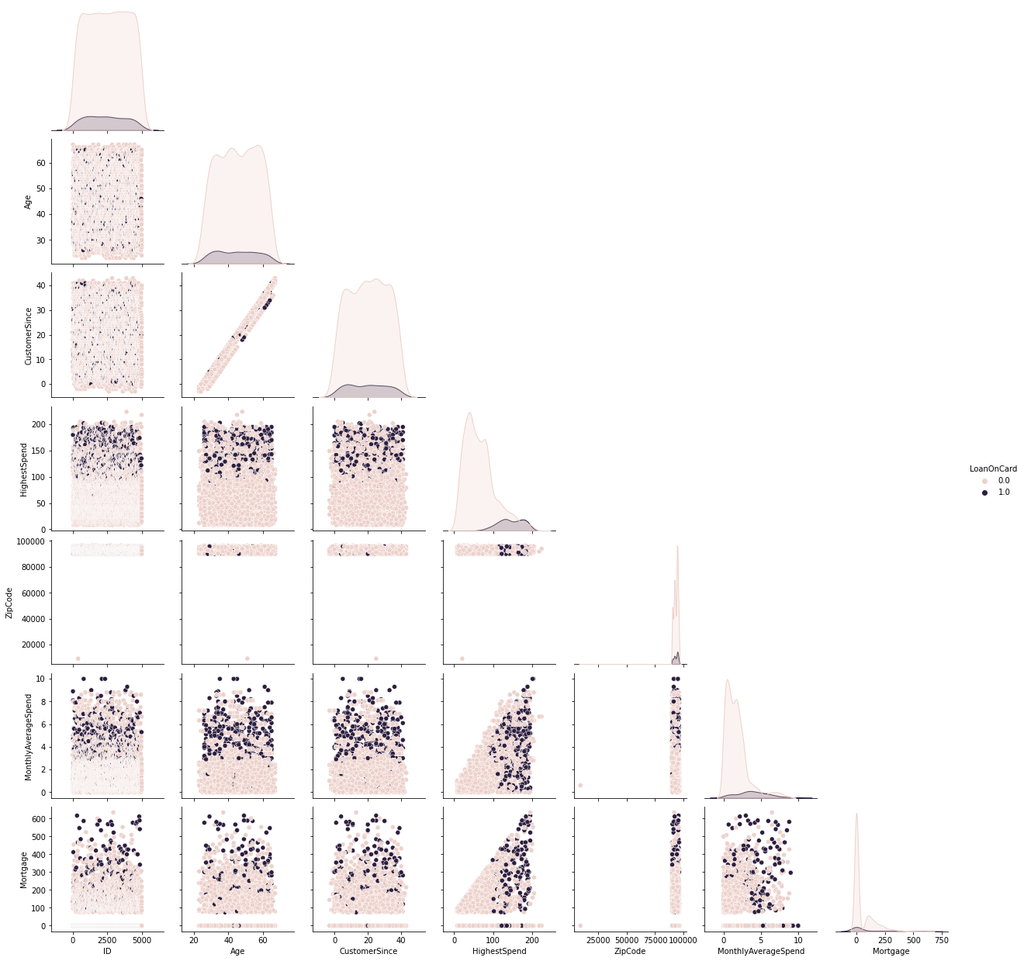

```python
# Check if LoanOnCard is influenced by any numerical variable
sns.pairplot(data=bank_data,hue='LoanOnCard',corner=True);
```

*Thus, it would be prudent to drop the missing values in LoanOnCard as number of missing rows is only 20 (0.4 %) out of 5000 total rows.*

```python
# Drop Missing Rows
bank_data = bank_data.dropna()
#Reset the index
bank_data = bank_data.reset_index(drop=True)
#Display new dataframe head
bank_data.head()
```

|  | ID | Age | CustomerSince | HighestSpend | ZipCode | HiddenScore | MonthlyAverageSpend | Level | Mortgage | Security | FixedDepositAccount | InternetBanking | CreditCard | LoanOnCard |
| --- | --- | --- | --- | --- | --- | --- | --- | --- | --- | --- | --- | --- | --- | --- |
| 0 | 10 | 34 | 9 | 180 | 93023 | 1 | 8.9 | 3 | 0 | 0 | 0 | 0 | 0 | 1.0 |
| 1 | 11 | 65 | 39 | 105 | 94710 | 4 | 2.4 | 3 | 0 | 0 | 0 | 0 | 0 | 0.0 |
| 2 | 12 | 29 | 5 | 45 | 90277 | 3 | 0.1 | 2 | 0 | 0 | 0 | 1 | 0 | 0.0 |
| 3 | 13 | 48 | 23 | 114 | 93106 | 2 | 3.8 | 3 | 0 | 1 | 0 | 0 | 0 | 0.0 |
| 4 | 14 | 59 | 32 | 40 | 94920 | 4 | 2.5 | 2 | 0 | 0 | 0 | 1 | 0 | 0.0 |

```python
# Change datatype of LoanOnCard to Categorical

bank_data['LoanOnCard'] = bank_data.LoanOnCard.astype('category')

# Check datatypes

bank_data.info()
```

```
<class 'pandas.core.frame.DataFrame'>
RangeIndex: 4980 entries, 0 to 4979
Data columns (total 14 columns):
 #   Column               Non-Null Count  Dtype
---  ------               --------------  -----
 0   ID                   4980 non-null   int64
 1   Age                  4980 non-null   int64
 2   CustomerSince        4980 non-null   int64
 3   HighestSpend         4980 non-null   int64
 4   ZipCode              4980 non-null   int64
 5   HiddenScore          4980 non-null   object
 6   MonthlyAverageSpend  4980 non-null   float64
 7   Level                4980 non-null   object
 8   Mortgage             4980 non-null   int64
 9   Security             4980 non-null   object
 10  FixedDepositAccount  4980 non-null   object
 11  InternetBanking      4980 non-null   object
 12  CreditCard           4980 non-null   object
 13  LoanOnCard           4980 non-null   category
dtypes: category(1), float64(1), int64(6), object(6)
memory usage: 510.9+ KB
```

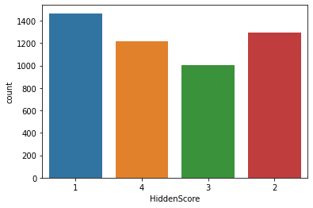

```python
# Check for unexpected values in categorical variable: HiddenScore
sns.countplot(x=bank_data['HiddenScore']);
```

*HiddenScore does not have unexpected values.*

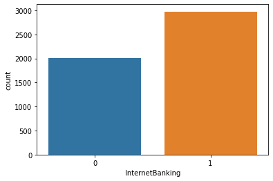

```python
# Check for unexpected values in categorical variable: InternetBanking
sns.countplot(x=bank_data['InternetBanking']);
```

*InternetBanking does not have unexpected values*

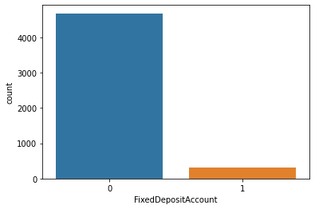

```python
# Check for unexpected values in categorical variable: FixedDepositAccount
sns.countplot(x=bank_data['FixedDepositAccount']);
```

*FixedDepositAccount does not have unexpected values*

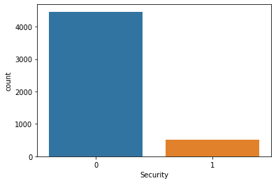

```python
# Check for unexpected values in categorical variable: Security
sns.countplot(x=bank_data['Security']);
```

*Security does not have unexpected values*

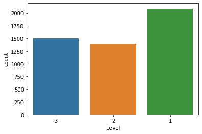

```python
# Check for unexpected values in categorical variable: Level
sns.countplot(x=bank_data['Level']);
```

*Level does not have unexpected values*

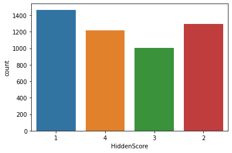

```python
# Check for unexpected values in categorical variable: HiddenScore
sns.countplot(x=bank_data['HiddenScore']);
```

*HiddenScore does not have unexpected values*

*None of the categorical variables have any unexpected values.*

## **3. Data Preparation and model building:**

### **A. Split data into X and Y.**

[Recommended to drop ID & ZipCode. LoanOnCard is target Variable]

```python
# Drop ID, ZipCode and LoanOnCard from Independent Variables
X = bank_data.drop(['ID','ZipCode','LoanOnCard'], axis=1)
# Dispaly Independent Variables
X.head()
```

|  | Age | CustomerSince | HighestSpend | HiddenScore | MonthlyAverageSpend | Level | Mortgage | Security | FixedDepositAccount | InternetBanking | CreditCard |
| --- | --- | --- | --- | --- | --- | --- | --- | --- | --- | --- | --- |
| 0 | 34 | 9 | 180 | 1 | 8.9 | 3 | 0 | 0 | 0 | 0 | 0 |
| 1 | 65 | 39 | 105 | 4 | 2.4 | 3 | 0 | 0 | 0 | 0 | 0 |
| 2 | 29 | 5 | 45 | 3 | 0.1 | 2 | 0 | 0 | 0 | 1 | 0 |
| 3 | 48 | 23 | 114 | 2 | 3.8 | 3 | 0 | 1 | 0 | 0 | 0 |
| 4 | 59 | 32 | 40 | 4 | 2.5 | 2 | 0 | 0 | 0 | 1 | 0 |

```python
# Drop all variables except Target Variable LoanOnCard
Y = bank_data['LoanOnCard']
print(Y)
```

```
0       1.0
1       0.0
2       0.0
3       0.0
4       0.0
       ...
4975    0.0
4976    0.0
4977    0.0
4978    0.0
4979    0.0
Name: LoanOnCard, Length: 4980, dtype: category
Categories (2, float64): [0.0, 1.0]
```

### **B. Split data into train and test. Keep 25% data reserved for testing.**

```python
# Split X & Y into Train & Test
# Test Data Size should be 25% of the total dataset
x_train, x_test, y_train, y_test = train_test_split(X, Y, test_size=0.25, random_state=2)
print("{0:0.2f}% data is in training set".format((len(x_train)/len(bank_data.index)) * 100))
print("{0:0.2f}% data is in test set".format((len(x_test)/len(bank_data.index)) * 100))
```

```
75.00% data is in training set
25.00% data is in test set
```

### **C. Train a Supervised Learning Classification base model - Logistic Regression.**

```python
from sklearn.linear_model import LogisticRegression

# Fit the model on train
LogReg1 = LogisticRegression(solver='liblinear',random_state=2)
LogReg1.fit(x_train, y_train)

# Predict on Test
y_predict1 = LogReg1.predict(x_test)

# Print Accuracy of Test & Train Data
print('Accuracy of Training Data',LogReg1.score(x_train, y_train))
print('Accuracy of Test Data',LogReg1.score(x_test, y_test))
```

```
Accuracy of Training Data 0.9504685408299867
Accuracy of Test Data 0.9534136546184739
```

*The accuracies of predicting the classes in training and test data is around 95% in each case.*

### **D. Print evaluation metrics for the model and clearly share insights.**

```
Confusion Matrix
```

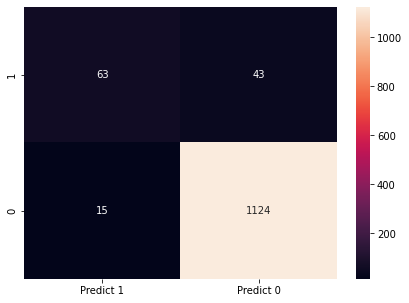

```python
# Let's plot a confusion matrix first
print('Confusion Matrix')

cm=metrics.confusion_matrix(y_test, y_predict1, labels=[1, 0])

df_cm = pd.DataFrame(cm, index = [i for i in ["1","0"]],
                  columns = [i for i in ["Predict 1","Predict 0"]])
plt.figure(figsize = (7,5));
sns.heatmap(df_cm, annot=True, fmt='d');
```

*From the confusion matrix*

*True Positives (TP): we correctly predicted that they do have LoanOnCard 63*

*True Negatives (TN): we correctly predicted that they don't have LoanOnCard 1124*

*False Positives (FP): we incorrectly predicted that they do have LoanOnCard (a "Type I error") 15 Falsely predict positive Type I error*

*False Negatives (FN): we incorrectly predicted that they don't have diabetes (a "Type II error") 43 Falsely predict negative Type II error*

```python
# Let's print the classification report with additional performance metrics
target_names = ['1','0']
print(classification_report(y_test, y_predict1, target_names=target_names))
```

```
              precision    recall  f1-score   support

           1       0.96      0.99      0.97      1139
           0       0.81      0.59      0.68       106

    accuracy                           0.95      1245
   macro avg       0.89      0.79      0.83      1245
weighted avg       0.95      0.95      0.95      1245
```

```python
# Check for ROC_AUC scores
from sklearn.metrics import roc_auc_score

# Print ROC_AUC Score
print(f'Area Under Curve: {roc_auc_score(y_test, y_predict1)}')
```

```
Area Under Curve: 0.7905850878791393
```

### **E. Balance the data using the right balancing technique.**

i. Check distribution of the target variable

ii. Say output is class A : 20% and class B : 80%

iii. Here you need to balance the target variable as 50:50.

iv. Try appropriate method to achieve the same.

```python
# Imbalance in Category LoanOnCard
print("Original LoanOnCard True Values    : {0} ({1:0.2f}%)".format(len(bank_data.loc[bank_data['LoanOnCard'] == 1]), (len(bank_data.loc[bank_data['LoanOnCard'] == 1])/len(bank_data.index)) * 100))
print("Original LoanOnCard False Values   : {0} ({1:0.2f}%)".format(len(bank_data.loc[bank_data['LoanOnCard'] == 0]), (len(bank_data.loc[bank_data['LoanOnCard'] == 0])/len(bank_data.index)) * 100))
print("")
print("Training LoanOnCard True Values    : {0} ({1:0.2f}%)".format(len(y_train[y_train[:] == 1]), (len(y_train[y_train[:] == 1])/len(y_train)) * 100))
print("Training LoanOnCard False Values   : {0} ({1:0.2f}%)".format(len(y_train[y_train[:] == 0]), (len(y_train[y_train[:] == 0])/len(y_train)) * 100))
print("")
print("Test LoanOnCard True Values        : {0} ({1:0.2f}%)".format(len(y_test[y_test[:] == 1]), (len(y_test[y_test[:] == 1])/len(y_test)) * 100))
print("Test LoanOnCard False Values       : {0} ({1:0.2f}%)".format(len(y_test[y_test[:] == 0]), (len(y_test[y_test[:] == 0])/len(y_test)) * 100))
print("")
```

```
Original LoanOnCard True Values    : 480 (9.64%)
Original LoanOnCard False Values   : 4500 (90.36%)

Training LoanOnCard True Values    : 374 (10.01%)
Training LoanOnCard False Values   : 3361 (89.99%)

Test LoanOnCard True Values        : 106 (8.51%)
Test LoanOnCard False Values       : 1139 (91.49%)
```

*We can balance the class weights while retraining the above model by adding an additional parameter of class_weight.*

### **F. Again train the same previous model on balanced data.**

```python
# Fit the model on train
LogReg2 = LogisticRegression(solver='liblinear',random_state=2,class_weight='balanced')
LogReg2.fit(x_train, y_train)

# Predict on Test
y_predict2 = LogReg2.predict(x_test)

# Print Accuracy of Test & Train Data
print('Accuracy of Training Data',LogReg2.score(x_train, y_train))
print('Accuracy of Test Data',LogReg2.score(x_test, y_test))
```

```
Accuracy of Training Data 0.8987951807228916
Accuracy of Test Data 0.8811244979919679
```

### **G. Print evaluation metrics and clearly share differences observed.**

```python
# Print ROC_AUC Score
print(f'Area Under Curve: {roc_auc_score(y_test, y_predict2)}')
```

```
Area Under Curve: 0.8708607351698776
```

*By using class_weight parameter to balance the data, there is a drop in accuracy of the model. But an increase in AUC is seen.*

```
Confusion Matrix
```

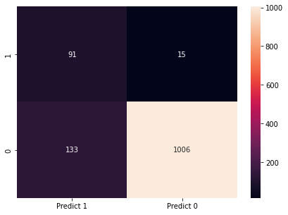

```python
# Print Confusion Matrix
print('Confusion Matrix')
cm=metrics.confusion_matrix(y_test, y_predict2, labels=[1, 0])

df_cm = pd.DataFrame(cm, index = [i for i in ["1","0"]],
                  columns = [i for i in ["Predict 1","Predict 0"]])
plt.figure(figsize = (7,5))
sns.heatmap(df_cm, annot=True, fmt='d');
```

*From the confusion matrix*

*True Positives (TP): we correctly predicted that they do have LoanOnCard 91 (an increase from 63 from previous model)*

*True Negatives (TN): we correctly predicted that they don't have LoanOnCard 1006 (a reduction from 1124 from previous model)*

*False Positives (FP): we incorrectly predicted that they do have LoanOnCard (a "Type I error") 133 Falsely predict positive Type I error (an increase from 15 from previous model)*

*False Negatives (FN): we incorrectly predicted that they don't have diabetes (a "Type II error") 15 Falsely predict negative Type II error (a reduction from 43 from previous model)*

```python
# Print Classification Report
print(classification_report(y_test, y_predict2, target_names=target_names))
```

```
              precision    recall  f1-score   support

           1       0.99      0.88      0.93      1139
           0       0.41      0.86      0.55       106

    accuracy                           0.88      1245
   macro avg       0.70      0.87      0.74      1245
weighted avg       0.94      0.88      0.90      1245
```

*Improvement in Performance Metrics*

## **4. Performance Improvement:**

### **A. Train a base model each for SVM, KNN.**

```python
# Base KNN Model

# Instantiate learning model
knn4 = KNeighborsClassifier()

# Fitting the model
knn4.fit(x_train, y_train)

# Predict test data
y_pred4 = knn4.predict(x_test)

# Print Accuracy Scores for KNN
print('Accuracy of Training Data',knn4.score(x_train, y_train))
print('Accuracy of Test Data',knn4.score(x_test, y_test))
```

```
Accuracy of Training Data 0.9413654618473896
Accuracy of Test Data 0.9140562248995984
```

```python
# Classification Report
print(classification_report(y_test, y_pred4, target_names=target_names))
```

```
              precision    recall  f1-score   support

           1       0.95      0.96      0.95      1139
           0       0.49      0.42      0.45       106

    accuracy                           0.91      1245
   macro avg       0.72      0.69      0.70      1245
weighted avg       0.91      0.91      0.91      1245
```

```python
# Print ROC_AUC Score for KNN
print(f'Area Under Curve for KNN: {roc_auc_score(y_test, y_pred4)}')
```

```
Area Under Curve for KNN: 0.6877929994864743
```

```
Confusion Matrix - KNN
```

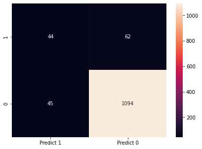

```python
# Print Confusion Matrix for KNN
print('Confusion Matrix - KNN')
cm=metrics.confusion_matrix(y_test, y_pred4, labels=[1, 0])

df_cm = pd.DataFrame(cm, index = [i for i in ["1","0"]],
                  columns = [i for i in ["Predict 1","Predict 0"]])
plt.figure(figsize = (7,5))
sns.heatmap(df_cm, annot=True, fmt='d');
```

```python
# Base SVM Model
from sklearn.svm import SVC

# Building a Support Vector Machine on train data
svc1 = SVC()
svc1.fit(x_train, y_train)

svc_y_pred = svc1.predict(x_test)

# check the accuracy on the training & test set
print(svc1.score(x_train, y_train))
print(svc1.score(x_test, y_test))
```

```
0.9078982597054887
0.9124497991967871
```

```python
# Classification Report
print(classification_report(y_test, svc_y_pred, target_names=target_names))
```

```
              precision    recall  f1-score   support

           1       0.92      0.98      0.95      1139
           0       0.45      0.14      0.22       106

    accuracy                           0.91      1245
   macro avg       0.69      0.56      0.58      1245
weighted avg       0.88      0.91      0.89      1245
```

```python
# Print ROC_AUC Score for SVM
print(f'Area Under Curve for KNN: {roc_auc_score(y_test, svc_y_pred)}')
```

```
Area Under Curve for KNN: 0.5628530488511936
```

```
Confusion Matrix - SVM
```

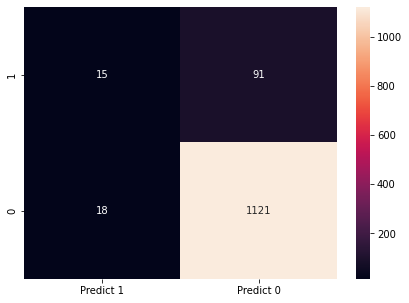

```python
# Print Confusion Matrix for SVM
print('Confusion Matrix - SVM')
cm=metrics.confusion_matrix(y_test, svc_y_pred, labels=[1, 0])

df_cm = pd.DataFrame(cm, index = [i for i in ["1","0"]],
                  columns = [i for i in ["Predict 1","Predict 0"]])
plt.figure(figsize = (7,5))
sns.heatmap(df_cm, annot=True, fmt='d');
```

### **B. Tune parameters for each of the models wherever required and finalize a model.**

```python
# Check descriptive statistics
x_train.describe(include='all').transpose()
```

|  | count | unique | top | freq | mean | std | min | 25% | 50% | 75% | max |
| --- | --- | --- | --- | --- | --- | --- | --- | --- | --- | --- | --- |
| Age | 3735.0 | NaN | NaN | NaN | 45.418206 | 11.488808 | 23.0 | 35.0 | 45.0 | 55.0 | 67.0 |
| CustomerSince | 3735.0 | NaN | NaN | NaN | 20.173226 | 11.51084 | -3.0 | 10.0 | 20.0 | 30.0 | 43.0 |
| HighestSpend | 3735.0 | NaN | NaN | NaN | 73.781526 | 46.059775 | 8.0 | 39.0 | 63.0 | 99.0 | 224.0 |
| HiddenScore | 3735 | 4 | 1 | 1098 | NaN | NaN | NaN | NaN | NaN | NaN | NaN |
| MonthlyAverageSpend | 3735.0 | NaN | NaN | NaN | 1.937282 | 1.744489 | 0.0 | 0.7 | 1.5 | 2.5 | 10.0 |
| Level | 3735 | 3 | 1 | 1556 | NaN | NaN | NaN | NaN | NaN | NaN | NaN |
| Mortgage | 3735.0 | NaN | NaN | NaN | 56.197323 | 101.504459 | 0.0 | 0.0 | 0.0 | 100.0 | 635.0 |
| Security | 3735 | 2 | 0 | 3337 | NaN | NaN | NaN | NaN | NaN | NaN | NaN |
| FixedDepositAccount | 3735 | 2 | 0 | 3500 | NaN | NaN | NaN | NaN | NaN | NaN | NaN |
| InternetBanking | 3735 | 2 | 1 | 2239 | NaN | NaN | NaN | NaN | NaN | NaN | NaN |
| CreditCard | 3735 | 2 | 0 | 2623 | NaN | NaN | NaN | NaN | NaN | NaN | NaN |

*Scaling the data is necessary as mean and standard deviation are varying.*

```python
# import zscore for scaling the data
from scipy import stats

# Numerical Columns to be scaled
col_names=['Age', 'CustomerSince','HighestSpend','MonthlyAverageSpend','Mortgage']

# Scale the Data
# Apply zscore on independent features

# Create copy of training data
xtrainsc = x_train

# Apply Z-score scaling to numerical columns of training data
xtrainsc[col_names] = stats.zscore(xtrainsc[col_names])
xtrainsc.head()
```

|  | Age | CustomerSince | HighestSpend | HiddenScore | MonthlyAverageSpend | Level | Mortgage | Security | FixedDepositAccount | InternetBanking | CreditCard |
| --- | --- | --- | --- | --- | --- | --- | --- | --- | --- | --- | --- |
| 707 | 1.443493 | 1.462015 | -1.211230 | 3 | -0.365361 | 2 | -0.553718 | 0 | 0 | 1 | 0 |
| 1346 | 1.269387 | 1.201357 | -0.885523 | 2 | -0.938671 | 1 | 0.441445 | 0 | 0 | 1 | 0 |
| 1516 | -0.819882 | -0.710141 | -0.016970 | 4 | 0.035957 | 3 | 1.298665 | 0 | 0 | 1 | 0 |
| 3008 | 1.530546 | 1.635788 | -0.776954 | 3 | -1.053333 | 3 | 1.200134 | 0 | 0 | 1 | 1 |
| 764 | 0.224753 | 0.158722 | 0.525876 | 2 | 2.501191 | 1 | -0.553718 | 0 | 0 | 0 | 0 |

```python
# Create copy of test data
xtestsc = x_test

# Apply Z-score scaling to numerical columns of test data
xtestsc[col_names] = stats.zscore(xtestsc[col_names])
xtestsc.head()
```

|  | Age | CustomerSince | HighestSpend | HiddenScore | MonthlyAverageSpend | Level | Mortgage | Security | FixedDepositAccount | InternetBanking | CreditCard |
| --- | --- | --- | --- | --- | --- | --- | --- | --- | --- | --- | --- |
| 1302 | -1.155250 | -1.318453 | -0.565398 | 2 | -0.156415 | 2 | -0.561838 | 1 | 1 | 1 | 1 |
| 3510 | 0.776632 | 0.709800 | -0.543706 | 4 | 0.483292 | 2 | -0.561838 | 1 | 0 | 0 | 0 |
| 4043 | 0.161942 | 0.092506 | -1.086002 | 2 | -1.045213 | 3 | -0.561838 | 0 | 0 | 0 | 1 |
| 3017 | -1.594314 | -1.583008 | 1.820700 | 3 | -0.875379 | 2 | -0.561838 | 0 | 1 | 1 | 0 |
| 2146 | -1.155250 | -1.053899 | -1.064310 | 3 | -0.592322 | 3 | -0.561838 | 0 | 0 | 1 | 1 |

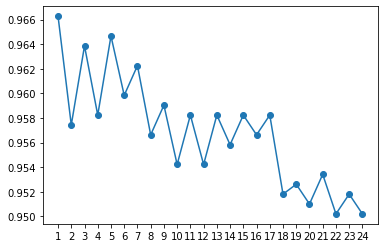

```python
# Tuning KNN Model
# Check for optimal value of k
kscores = []
for i in range(1,25):
  knn = KNeighborsClassifier(n_neighbors = i)
  knn.fit(xtrainsc, y_train)
  s = knn.score(xtestsc, y_test)
  kscores.append(s)
plt.plot(range(1,25), kscores, 'o-')
plt.xticks(range(1,25))
plt.show()
```

```python
# Modified KNN Model with k=1

# Instantiate learning model
knn5 = KNeighborsClassifier(n_neighbors=1)

# Fitting the model
knn5.fit(xtrainsc, y_train)

# Predict test data
y_pred5 = knn5.predict(xtestsc)

# Print Accuracy Scores for KNN
print('Accuracy of Training Data',knn5.score(xtrainsc, y_train))
print('Accuracy of Test Data',knn5.score(xtestsc, y_test))
```

```
Accuracy of Training Data 1.0
Accuracy of Test Data 0.9662650602409638
```

*knn5 is the final tuned knn model*

```python
# Tuning SVM Model

# Building a Support Vector Machine on train data
svc2 = SVC()
svc2.fit(xtrainsc, y_train)

# check the accuracy on the training & test set
print(svc2.score(xtrainsc, y_train))
print(svc2.score(xtestsc, y_test))
```

```
0.9796519410977242
0.9751004016064257
```

*Accuracy has increased simply through scaling. Let's add additional parameters to check if further improvement can be made.*

```python
# Building a Support Vector Machine on train data
svc3 = SVC(gamma=0.025, C=3)
svc3.fit(xtrainsc, y_train)

# check the accuracy on the training & test set
print(svc3.score(xtrainsc, y_train))
print(svc3.score(xtestsc, y_test))
```

```
0.978045515394913
0.9710843373493976
```

*Not much improvement is observed by adding gamma and C parameters.*

```python
# Building a Support Vector Machine on train data
svc4 = SVC(C= 3, kernel='linear', gamma=0.025)
svc4.fit(xtrainsc, y_train)

# check the accuracy on the training & test set
print(svc4.score(xtrainsc, y_train))
print(svc4.score(xtestsc, y_test))
```

```
0.9528781793842035
0.9550200803212852
```

*Linear kernel has reduced the accuracy of the model. We reject it.*

```python
# Building a Support Vector Machine on train data
svc5 = SVC(kernel='rbf')
svc5.fit(xtrainsc, y_train)

# check the accuracy on the training & test set
print(svc5.score(xtrainsc, y_train))
print(svc5.score(xtestsc, y_test))
```

```
0.9796519410977242
0.9751004016064257
```

*RBF Kernel has improved the accuracy of the model but it is same as the base SVM model in which data was scaled.*

```python
# Building a Support Vector Machine on train data
svc6 = SVC(kernel='poly')
svc6.fit(xtrainsc, y_train)

# Predict Test Data
svc_y_pred6 = svc6.predict(xtestsc)

# check the accuracy on the training & test set
print(svc6.score(xtrainsc, y_train))
print(svc6.score(xtestsc, y_test))
```

```
0.9820615796519411
0.976706827309237
```

*Poly kernel has improved the accuracy further above all the SVM models tested before it.*

```python
# Building a Support Vector Machine on train data
svc7 = SVC(kernel='sigmoid')
svc7.fit(xtrainsc, y_train)

# check the accuracy on the training & test set
print(svc7.score(xtrainsc, y_train))
print(svc7.score(xtestsc, y_test))
```

```
0.8305220883534137
0.8337349397590361
```

*Sigmoid kernel reduces the accuracy achieved prior.*

*We finalize svc6 model which has a poly kernel.*